# AIA, Licenciamento e Planejamento Ambiental

Análise Ambiental · Aula 5.1

Prof. Dr. Luiz Diego Vidal Santos

## Abertura Visão Geral da Aula

Roteiro da aula Tópicos estruturantes

- 1 Política Nacional do Meio Ambiente (Lei 6.938/1981): SISNAMA e os 13 Instrumentos
- 2 Competências Federativas (LC 140/2011) e Licenciamento na Bahia (INEMA/CEPRAM)
- 3 Processo de AIA, Tipos de Estudo (EIA/RIMA, RAS, PBA, AAE) e Licenças (LP, LI, LO)
- 4 As Nove Etapas da AIA: Triagem, Escopo, Termo de Referência (TR) e Plano de Trabalho
- 5 Diagnóstico de Base e Áreas de Influência (ADA, AID e AII)
- 6 Métodos de AIA (Checklists, Matriz de Leopold, Redes de Interação, SIG)
- 7 Mitigação, Compensação (SNUC Art. 36), Monitoramento e Audiência Pública

Objetivo da aula Arquitetura normativa e técnica

Dominar a arquitetura institucional e normativa da Política Nacional do Meio Ambiente (Lei 6.938/1981, CONAMA 01/1986 e 237/1997, LC 140/2011, Lei 15.190/2025 e Lei Estadual BA 10.431/2006) e operar todas as etapas metodológicas da Avaliação de Impacto Ambiental (AIA) e do EIA/RIMA.

Leitura de apoio Referência principal

SÁNCHEZ, L. E. (2020), capítulos 4 a 12 (processo de AIA, escopo, estudos de base, métodos de identificação/previsão e plano de gestão ambiental).

# PNMA, SISNAMA e Competências Legais

## PNMA Por que existe uma Política Nacional e um Sistema de Licenciamento?

01 · Ruptura histórica Do controle pontual à prevenção

Antes da **Lei nº 6.938/1981 (PNMA)**, a atuação pública ambiental era fragmentada e majoritariamente reativa após a ocorrência do dano.

02 · Princípios basilares Preventivo e poluidor-pagador

Empreendimentos com potencial degradador passam a ser avaliados **antes** da instalação, vinculando o desenvolvimento econômico à conservação e à reparação de danos.

03 · Arranjo federativo Por que organizar no SISNAMA?

Em uma federação, é preciso separar claramente quem formula normas técnicas (CONAMA), quem coordena a política (MMA) e quem licencia ou fiscaliza em cada esfera (União, estados e municípios).

A PNMA institui a prevenção prévia ao licenciamento e articula os três entes federativos sob diretrizes técnicas comuns.

## SISNAMA Estrutura do SISNAMA (Art. 6º)

| Nível no SISNAMA | Órgão / Entidade | Função Principal |
| --- | --- | --- |
| **1. Órgão Superior** | Conselho de Governo | Assessorar o Presidente na formulação de diretrizes nacionais |
| **2. Órgão Consultivo e Deliberativo** | **CONAMA** | Estabelecer normas, padrões e critérios (ex.: Res. 01/86, 237/97, 357/05) |
| **3. Órgão Central** | **MMA** (Ministério do Meio Ambiente) | Planejar, coordenar e supervisionar a política nacional |
| **4. Órgãos Executores** | **IBAMA** e **ICMBio** | Licenciamento federal, fiscalização (IBAMA) e gestão das UCs federais (ICMBio) |
| **5. Órgãos Seccionais** | Órgãos Estaduais (na Bahia: **SEMA / CEPRAM / INEMA**) | Licenciamento estadual, outorga hídrica e fiscalização |
| **6. Órgãos Locais** | Secretarias e Conselhos Municipais | Licenciamento e controle de impacto ambiental de âmbito local |

Na Bahia, a política estadual integra **SEMA** (formulação), **CEPRAM** (deliberação normativa e tipologias) e **INEMA** (execução do licenciamento e outorga).

## Instrumentos Os 13 Instrumentos da PNMA (Art. 9º)

Incisos I a VII Normatização, planejamento e controle

1. Estabelecimento de **padrões de qualidade ambiental**;
2. **Zoneamento Ambiental** (regulamentado pelo Dec. 4.297/2002 como **ZEE**);
3. **Avaliação de Impactos Ambientais (AIA)**;
4. **Licenciamento** e revisão de atividades efetiva ou potencialmente poluidoras;
5. Incentivos à produção e instalação de equipamentos e tecnologias limpas;
6. Criação de **espaços territoriais especialmente protegidos** (UCs — Lei 9.985/2000);
7. Sistema Nacional de Informações sobre o Meio Ambiente (**SINIMA**).

Incisos VIII a XIII Cadastro, sanção e incentivos

8. Cadastro Técnico Federal de Atividades e Instrumentos de Defesa Ambiental;
9. Penalidades disciplinares ou compensatórias;
10. Relatório de Qualidade do Meio Ambiente (**RQMA**);
11. Garantia da prestação de informações relativas ao Meio Ambiente;
12. Cadastro Técnico Federal de atividades potencialmente poluidoras (**CTF/APP**);
13. Instrumentos econômicos (concessão florestal, servidão ambiental, seguro ambiental e **PSA**).

## Federativo Competências Federativas no Licenciamento (LC nº 140/2011)

Art. 13 · Regra de Ouro Unicidade do licenciamento

Os empreendimentos são licenciados ou autorizados ambientalmente por **um único ente federativo**, sendo vedada a duplicidade de licenciamento.

Arts. 7º, 8º e 9º Critério definidor por ente

- **União (IBAMA — Art. 7º):** Brasil e país limítrofe; mar territorial/plataforma continental; terras indígenas; UCs instituídas pela União (exceto APA); em **2 ou mais Estados**; caráter militar; material radioativo/nuclear.
- **Municípios (Art. 9º):** **impacto ambiental de âmbito local** (tipologias do Conselho Estadual — na Bahia, **CEPRAM**), com órgão capacitado e Conselho Municipal ativo.
- **Estados (Art. 8º — residual geral):** demais empreendimentos, em 2 ou mais municípios ou em UCs estaduais (exceto APA).

Art. 14, § 1º · Lei 6.938/1981 Responsabilidade Objetiva

No Direito Ambiental brasileiro, a responsabilidade civil por dano ambiental é **objetiva** (**Teoria do Risco Integral**): **independe da existência de culpa**, bastando comprovar o **dano** e o **nexo de causalidade** entre a atividade do poluidor e a degradação diagnosticada pela perícia geográfica/ambiental.

# O Processo de AIA e o Licenciamento

## AIA O que é a AIA

Definições clássicas Previsão e magnitude

- **Sánchez (2020):** conjunto de procedimentos voltados a **prever**, **analisar** e **comunicar** as consequências ambientais prováveis de uma ação proposta antes que a decisão seja tomada.
- **Bitar & Ortega (1998):** série de procedimentos legais, institucionais e técnico-científicos para **caracterizar impactos potenciais** e **prever magnitude e importância**.

Objetivos e abordagem Síntese interdisciplinar

- **Impedir a degradação**, **reduzir a degradação** e **promover o desenvolvimento sustentável**.
- Abordagem **interdisciplinar**: meios físico, biótico e socioeconômico integrados.

Quatro papéis Funções da AIA

- **Técnica:** identificar e quantificar impactos.
- **Decisória:** subsidiar a autorização ou a negação do projeto.
- **De negociação:** estabelecer medidas mitigadoras e compensatórias.
- **De aprendizado social:** produzir conhecimento territorial público.

A AIA não é um documento: é um **processo** que atravessa todo o ciclo de vida do empreendimento.

## Normas Marco regulatório: consultar a versão consolidada

| Referência | Função no estudo ambiental |
| --- | --- |
| CF/1988, art. 225, §1º, IV | Estudo prévio de impacto para atividades de significativa degradação, com publicidade |
| Lei 6.938/1981 | PNMA, SISNAMA e instrumentos |
| LC 140/2011 | Distribuição de ações administrativas entre os entes |
| Lei 15.190/2025, com alterações da Lei 15.300/2025 | Marco geral do licenciamento; modalidades, estudos e procedimentos |
| CONAMA 01/1986 e 237/1997 | Referenciais de AIA e licenciamento, lidos em compatibilidade com a legislação posterior |
| Lei BA 10.431/2006, Decreto 14.024/2012 e atos posteriores | Política e procedimentos estaduais; verificar o enquadramento aplicável no INEMA/SEIA e CEPRAM |

**Base de consulta:** novembro de 2026. O estudo deve registrar a norma e sua versão aplicáveis ao processo.

## Bahia Enquadramento na Bahia: um roteiro de consulta

**01 · Atividade e porte:** identificar atividade, localização, porte e potencial poluidor do empreendimento.

**02 · Competência federativa:** verificar competência federal, estadual ou municipal nos termos da **LC 140/2011**.

**03 · Normativa baiana:** consultar as tipologias e atos vigentes do **INEMA/SEIA** e do **CEPRAM**.

**04 · Restrições territoriais:** conferir restrições e manifestações relativas a vegetação, água, patrimônio e territórios protegidos.

**05 · Termo de referência:** obter o termo de referência e registrar estudos e autorizações exigidos.

Não transpor automaticamente uma matriz de outro estado. **LP/LI/LO** é um procedimento possível; a modalidade depende do enquadramento legal da atividade e do processo.

## Licenciamento Licenciamento trifásico: LP, LI e LO

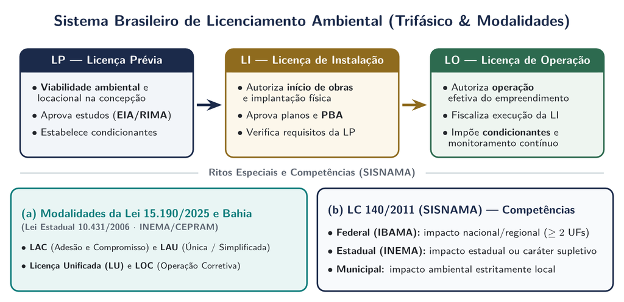

Sistema Brasileiro de Licenciamento Ambiental: rito trifásico (LP, LI, LO), modalidades da Lei 15.190/2025 e Bahia, e competências da LC 140/2011.

Sistema brasileiro de licenciamento: rito trifásico, modalidades e competências Elaboração própria (TikZ) · verificar os estudos, condicionantes e autorizações exigidos em cada etapa

O esquema representa o rito trifásico (**LP → LI → LO**) em articulação com os ritos especiais e as competências do SISNAMA.

## Modalidades Outras modalidades previstas no marco geral

| Sigla | Modalidade (Art. 5º da Lei 15.190/2025) |
| --- | --- |
| **LAU** | Licença Ambiental Única |
| **LAC** | Licença por Adesão e Compromisso |
| **LOC** | Licença de Operação Corretiva |
| **LAE** | Licença Ambiental Especial |

Condições de aplicação Enquadramento específico

As hipóteses e requisitos variam por modalidade. A existência de procedimento simplificado não dispensa as demais exigências legalmente cabíveis (outorga, supressão vegetal, patrimônio).

Referência normativa Consulta ao texto vigente

[Texto consolidado da Lei 15.190/2025 (Câmara dos Deputados)](https://www2.camara.leg.br/legin/fed/lei/2025/lei-15190-8-agosto-2025-797833-normaatualizada-pl.html).

LAU · Única LAC · Adesão e Compromisso LOC · Corretiva LAE · Especial

## Etapas Fluxo metodológico da AIA e hierarquia de mitigação

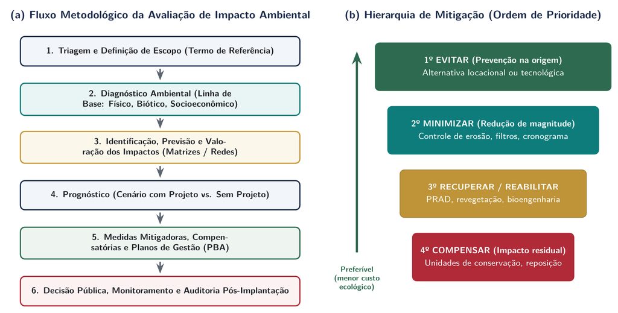

Fluxo metodológico da Avaliação de Impacto Ambiental em seis blocos e ordem de prioridade da Hierarquia de Mitigação.

Fluxo metodológico da AIA (a) e ordem de prioridade na mitigação (b) Elaboração própria (TikZ) · articulação entre triagem, diagnóstico, previsão, prognóstico, gestão e auditoria

A sequência metodológica vincula o **diagnóstico** e a **previsão de impactos** à ordem decrescente de preferência da mitigação: evitar é sempre menos custoso ecologicamente do que compensar.

## Etapas As nove etapas do processo de AIA

Etapas 1 a 5 Preparação, estudo e análise

- 1 **Apresentação da proposta** — descrição geral, localização e características técnicas.
- 2 **Triagem** — selecionar ações com potencial de alterações significativas e decidir pela necessidade de estudos aprofundados.
- 3 **Determinação do escopo** — abrangência e profundidade; preparação do termo de referência ou instruções técnicas.
- 4 **Elaboração do EIA** — avaliar componentes do projeto e processos ambientais alteráveis.
- 5 **Análise técnica** — conformidade ao TR, magnitude dos impactos e adequação das medidas propostas.

Etapas 6 a 9 Decisão e seguimento

- 6 **Consulta pública** — durante a realização do estudo ou após a sua conclusão.
- 7 **Decisão** — realizada pelo órgão ambiental competente.
- 8 **Monitoramento e gestão** — reduzir, eliminar e compensar impactos negativos, potencializar positivos e confirmar previsões com ajustes.
- 9 **Acompanhamento** — fiscalização, supervisão, auditoria e monitoramento contínuo.

As nove etapas são uma organização didática do processo de AIA. Os procedimentos administrativos variam conforme a modalidade e o enquadramento.

## Escopo Triagem e determinação do escopo

Etapa 2 Triagem

- Selecionar as ações que tenham potencial de causar **alterações ambientais significativas**.
- Decidir sobre a necessidade ou não de **estudos aprofundados**, ou de avaliação prévia.

Etapa 3 Determinação do escopo

- Estabelecer a **abrangência** (temas e questões) e a **profundidade** dos estudos (nível de detalhamento).
- Preparar o **termo de referência** ou as instruções técnicas.
- Identificar, prever, avaliar e gerenciar os impactos **significativos**, e só eles.

Critérios de focalização O que define o foco do escopo

- Importância dos **recursos ambientais ou culturais** envolvidos, ou vulnerabilidade das comunidades humanas.
- **Experiência profissional** dos analistas.
- **Opinião do público** e conhecimento local.

Escopo mal definido produz os dois erros clássicos: **estudo volumoso sobre o que não importa** e **silêncio sobre o impacto decisivo**.

## Planejamento Termo de referência e plano de trabalho

Sequência operacional Fluxo do estudo

1. Apresentação da **proposta**, características técnicas e **justificativa locacional**.
2. Seleção das **ações** potencialmente causadoras de alterações.
3. **Triagem e escopo**: abrangência, profundidade e questões prioritárias.
4. Preparação do **Termo de Referência**.
5. **Plano de trabalho** e **estudos de base** (diagnóstico).
6. Identificação e **previsão** dos impactos.
7. Análise técnica, **consulta pública** e decisão do órgão ambiental.
8. **Monitoramento** e plano de gestão.

Roteiro oficial Termo de Referência (TR)

Roteiro do órgão ambiental com o conteúdo mínimo do EIA/RIMA (meios físico, biótico e socioeconômico). A empresa pode detalhar além do mínimo, **jamais reduzi-lo**.

Lógica decisória Resposta aos impactos

**Evitar → Reduzir → Corrigir → Compensar**

# Diagnóstico, dados e áreas de influência

## Diagnóstico Estudos de base: o que o diagnóstico entrega

Função dos estudos de base Dinâmica e interações

Obter as informações necessárias à identificação e à previsão de impactos **específicas daquele empreendimento**.

- Mostram a **dinâmica ambiental** da área afetada.
- Utilizam **indicadores apropriados** para descrever as condições ambientais.
- Descrevem e analisam a **situação atual** da área de estudo.
- Levantam componentes e processos dos meios **físico, biótico e antrópico** e, sobretudo, as **interações** entre eles.

Planejamento dos estudos Produto do plano de trabalho

1. Definir o tipo de informação que se pretende coletar.
2. Definir se serão necessários dados primários e secundários.
3. Estabelecer as escalas temporal e espacial dos estudos.
4. Estabelecer os métodos de coleta.
5. Verificar a necessidade de análises laboratoriais e procedimentos de coleta.
6. Tratar e interpretar os dados.

Os resultados precisam possibilitar a comparação **multitemporal**: antes e depois da implantação do projeto.

## Território Áreas de influência: ADA, AID e AII

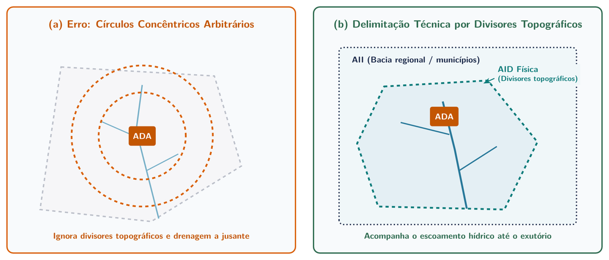

Comparação entre delimitação errônea por círculos concêntricos arbitrários e delimitação técnica por divisores topográficos e bacia.

Delimitação técnica por divisores topográficos vs. círculos arbitrários Elaboração própria (TikZ) · ADA, AID e AII devem acompanhar o escoamento hídrico e os vetores de impacto

Recortes espaciais ADA, AID e AII

- **ADA:** área que sofre a ação direta do planejamento, implantação, operação e desativação (impactos diretos de 1ª ordem).
- **AID:** obras e atividades, infraestrutura, transporte e distribuição de produtos, insumos e água.
- **AII:** conjunto ou parte dos municípios envolvidos e bacia hidrográfica abrangida.

Importante Especificidade por meio

A delimitação **varia com a categoria do impacto**: socioeconômico, físico e biótico exigem recortes próprios e justificados.

## Dados Dados primários e secundários

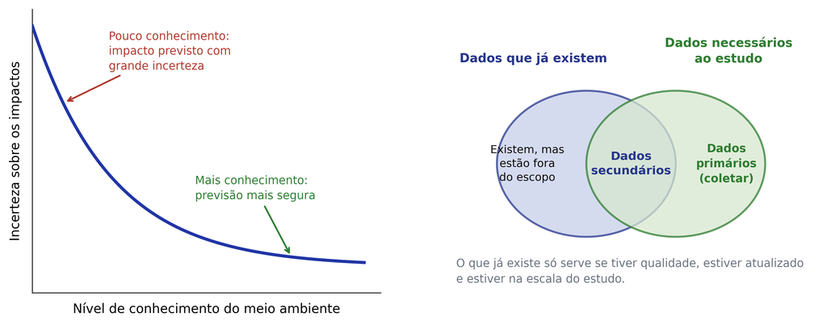

À esquerda, incerteza sobre os impactos decrescendo com o nível de conhecimento do meio; à direita, diagrama de conjuntos entre dados existentes, secundários e primários.

Redução da incerteza preditiva e triagem entre dados secundários e primários Dados existentes só entram no diagnóstico se tiverem qualidade, atualização e escala compatível

Coleta de campo Dados primários, por ordem de prioridade

- Diagnóstico dos elementos que **sofrerão maior impacto**.
- **Lacunas** de dados.
- **Especificidades locais**.

Acervo existente Dados secundários, condições de uso

- **Alta qualidade**.
- **Atualizados**.
- **Escala apropriada** ao estudo.

## Amostragem Desenho da amostragem

| Decisão | Alternativas | Quando usar cada uma |
| --- | --- | --- |
| **Cobertura** | Inventário ou amostragem | Inventário quando a área é pequena ou o elemento é raro; amostragem no restante |
| **Tempo** | Séries temporais ou amostragens únicas | Amostragem única quando a qualidade ou o elemento é **estável**, com pouca variação temporal |
| **Regime** | Contínua ou discreta | A **contínua** é mais empregada no monitoramento operacional; a **discreta** cobre a maior parte dos estudos de base |

Estratégia espacial Quando a área vale mais que o tempo

Para elementos estáveis e de pouca variação temporal, **a área amostrada é mais importante que a temporalidade**: cobre-se mais espaço em menos campanhas.

O inverso vale para qualidade da água e ruído, em que a variação intra-anual é o próprio objeto da medição.

# Identificação e avaliação de impactos

## Impactos Identificação preliminar dos impactos

Alterações prováveis Impactos típicos no meio

- Degradação dos recursos hídricos.
- Perda de solo e degradação da vegetação.
- Poluição sonora e degradação da qualidade do ar.

Procedimentos de triagem Como se chega a essa lista

- **Analogia** com casos similares e **experiência** de especialistas.
- **Consulta ao público** e restrições definidas **por via legal** (espécies raras e áreas protegidas).

Critério de esforço Nem todo impacto pesa igual

Alguns impactos deverão ser considerados **mais importantes que outros** e receber mais atenção no EIA. A identificação preliminar existe justamente para hierarquizar o esforço antes de gastá-lo.

Fonte do conhecimento Equipe multidisciplinar

Analogia com situações similares e experiência da **equipe multidisciplinar** ou de consultores externos são as duas vias mais usadas quando ainda não há dado primário.

## Ciclo de Vida Identificação por fase do ciclo de vida

| Fase | Exemplos de impacto |
| --- | --- |
| **Planejamento** | Tensão social e expectativa fundiária |
| **Implantação** | Supressão de vegetação, poeira, ruído, resíduos de construção |
| **Operação** | Efluentes, emissões, consumo de água, tráfego |
| **Desativação** | Demolição, reabilitação ou recuperação da área |

O mesmo impacto pode ocorrer em mais de uma fase, com gravidade diferente em cada uma.

| Transposição do São Francisco | Fases em que ocorre |
| --- | --- |
| Tensões e riscos sociais | Planejamento e construção |
| Aumento da emissão de poeira | Construção e operação |
| Aumento ou aparecimento de doenças | Construção e operação |
| Demanda por infraestrutura de saúde | Construção |
| Perda de terras agricultáveis | Construção |
| Geração de renda e empregos | Construção e operação |

## Métodos Métodos de identificação: panorama

Catálogo metodológico Os seis métodos clássicos

1. Métodos **ad hoc**.
2. **Listas de verificação** (*checklists*).
3. **Matrizes de interação**.
4. **Redes de interação** (diagramas de sistema).
5. **Superposição de cartas** (SIG).
6. **Modelos de simulação**.

E, na prática, a **combinação de métodos**, com dois ou mais aplicados em conjunto.

Referencial comparativo Como relacionar os impactos

- **Com empreendimento definido:** relacionar os impactos com **cada atividade** do empreendimento.
- **Sem empreendimento definido:** relacionar com **áreas modelo**, de alta qualidade ambiental.

Nenhum método isolado dá conta do estudo. A escolha depende do que se quer enxergar: impactos diretos, encadeamentos, conflitos espaciais ou dinâmica temporal.

## Leopold Matriz de Leopold

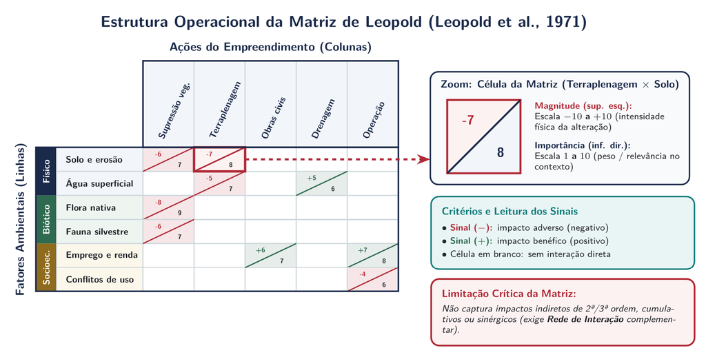

Estrutura operacional da Matriz de Leopold cruzando ações do empreendimento e fatores ambientais, com detalhe da célula (magnitude e importância).

Estrutura operacional da Matriz de Leopold (Leopold et al., 1971) Elaboração própria (TikZ) · magnitude (−10 a +10) no canto superior esquerdo e importância (1 a 10) no inferior direito

Leitura da célula Objetividade e hierarquização

- Cruza **componentes do projeto** (colunas) com **elementos do meio** (linhas).
- Cada célula recebe **magnitude** ($-10\text{ a }+10$) e **importância** ($1\text{ a }10$).
- É a matriz **mais utilizada** na prática brasileira para hierarquizar impactos diretos.

Restrições metodológicas Limitações críticas

- **Não capta impactos indiretos** (2ª/3ª ordem), cumulativos nem a dinâmica temporal.
- A pontuação **não é transferível** entre empreendimentos ou locais.

## Redes Redes de interação: cadeia de impactos indiretos

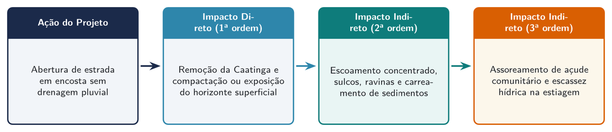

Rede de interação: abertura de estrada em encosta sem drenagem pluvial gerando impacto direto (1ª ordem) e impactos indiretos de 2ª e 3ª ordem até assoreamento de açude.

Cadeia causal em rede de interação: da ação inicial ao impacto indireto de 3ª ordem Elaboração própria (TikZ) · o mesmo encadeamento ocorre na impermeabilização urbana até cheias e perdas econômicas

Encadeamento causal O que a matriz não enxerga

A rede expõe o efeito em cascata até o dano socioambiental relevante (assoreamento do açude comunitário ou perdas econômicas por cheia urbana a vários elos da ação inicial).

Prevenção na origem Onde mitigar

Mitigar no elo final equivale a indenização ou desassoreamento corretivo; mitigar nos **elos iniciais** (drenagem adequada e manutenção de áreas permeáveis) é prevenção.

## Valoração Classificação dos impactos

| Atributo | O que expressa |
| --- | --- |
| **Magnitude** | Intensidade qualitativa ou quantitativa da alteração |
| **Duração** | Período de tempo em que o impacto deverá durar |
| **Reversibilidade** | Natural ou por intermédio de ação humana |
| **Relevância** | Conforme leis locais, nacionais ou tratados internacionais |
| **Probabilidade** | Estimativa de ocorrência do impacto |
| **Distribuição social** | Repartição desigual de riscos e benefícios ambientais |

| Elemento | Valor | Justificativa (exemplo) |
| --- | --- | --- |
| Vegetação terrestre | Pequeno | Vegetação é comum |
| Ictiofauna | Grande | Habitats aquáticos de qualidade; alimentação da população |
| Avifauna terrestre | Pequeno | Espécies comuns, não utilizadas para alimentação |
| Lazer e turismo | Médio | Uso atual limitado, com potencial para economia local |
| Arqueologia | Grande | Sítios relativamente raros e relevantes à história local |

# Mitigação, monitoramento e participação

## Mitigação Hierarquia da mitigação

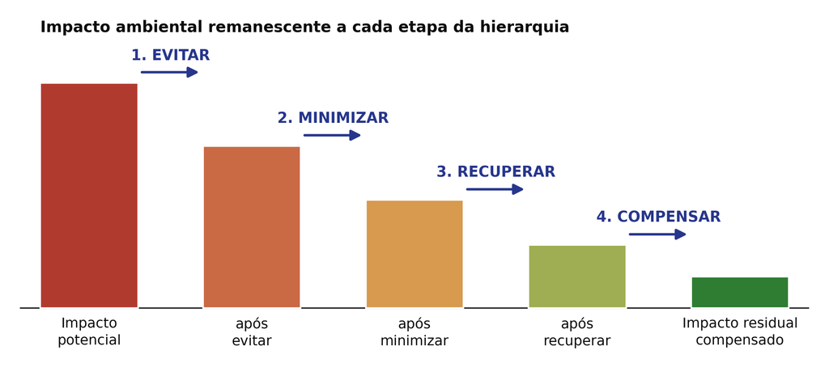

Hierarquia da mitigação: barras decrescentes do impacto potencial ao impacto residual compensado, com as etapas evitar, minimizar, recuperar e compensar.

Redução progressiva do impacto remanescente na hierarquia de mitigação Ordem de preferência técnica e legal, do maior efeito preventivo ao último recurso

**1. Evitar:** prevenir riscos e impactos alterando concepção ou traçado.

**2. Reduzir / minimizar:** atenuar magnitude ou duração dos impactos negativos.

**3. Corrigir / recuperar:** reabilitar após a ocorrência, ao final de cada etapa do ciclo de vida.

**4. Compensar:** contrabalançar apenas o **impacto residual** inevitável (Art. 36 da Lei 9.985/2000 — SNUC).

A hierarquia é uma **ordem de preferência**, não um cardápio equivalente: compensação é **último recurso**.

## Medidas Medidas mitigadoras típicas

| Categoria | Exemplo |
| --- | --- |
| **Construtivas** | Cortinas de drenagem, *sed-traps*, passagens de fauna |
| **Operacionais** | Educação ambiental, gestão de resíduos e efluentes |
| **Compensatórias** | Unidades de Conservação (SNUC Art. 36), reposição florestal |
| **Reparadoras** | PRAD, recomposição de APP e desassoreamento |
| **Valorização de benefícios** | Priorizar contratação e capacitação de mão de obra local |

Distinção essencial O que não é medida mitigadora

Exigências legais (licenças, outorga) e **monitoramento** não mitigam: mitigar é **agir sobre o impacto**. Monitorar apenas informa se a medida adotada está funcionando.

Medidas copiadas de outros empreendimentos costumam falhar; cada medida precisa ser ajustada ao contexto local.

## Gestão Monitoramento e PBA

Acompanhamento Plano de Monitoramento

- Indicadores específicos para cada impacto previsto e **linha de base** prévia.
- Fases **pré-operacional**, **operacional** e **pós-operacional**, com frequência compatível e limiares de alerta e ação corretiva.

Programas executivos Programas Básicos Ambientais (PBA)

Detalham as condicionantes da LP: **gestão e supervisão** (PGA, PCS, PEA, PGR), **monitoramento biofísico** (água, fauna, flora, erosão, ruído) e **recuperação/compensação** (PRAD e reassentamento).

Atividade avaliativa Estudo Orientado nº 4 (entrega Aula 10.1)

Selecionar um EIA/RIMA público (**IBAMA** ou **INEMA-BA**) e identificar:

1. Áreas de influência (**ADA, AID, AII**).
2. Três principais impactos previstos (físico, biótico e socioeconômico).
3. Lacunas no diagnóstico ambiental.
4. Coerência da hierarquia de mitigação.
5. Adequação do plano de monitoramento.

## Participação Participação pública

CONAMA nº 09/1987 Audiência e consulta pública

- Envolve grupos afetados positiva ou negativamente pela intervenção.
- Convocada pelo órgão licenciador sempre que julgar necessário, ou solicitada por **entidade civil**, **Ministério Público** ou **50 ou mais cidadãos**.
- Legitima a decisão, reduz conflitos e incorpora saberes territoriais locais.

Qualificação do estudo Contribuições do público

Proposição de medidas mitigadoras adequadas à realidade local e identificação de usos tradicionais e comunidades invisibilizadas nos dados secundários.

Atores envolvidos Quem participa

Poder Executivo e Legislativo, Ministério Público, órgãos públicos, conselhos (**CONAMA / CEPRAM / COMDEMA**), entidades da sociedade civil, comunidades tradicionais e cidadãos afetados.

Efeito jurídico Art. 2º, § 2º · Res. CONAMA 09/1987

Caso não seja realizada audiência pública regularmente solicitada, a licença concedida **não terá validade**.

## Prática Exercício: ler o impacto na imagem

Em dupla · 20 minutos Roteiro no Google Earth

Localize, em imagens **anteriores e posteriores** à obra, uma destas instalações:

- **UHE Pedra do Cavalo / Itapebi** (BA) ou **UHE Serra do Facão** (GO);
- **UHE Jirau** (RO) ou **Complexo Eólico no Piemonte da Diamantina** (BA).

Responda: (1) delimitação de **ADA, AID e AII**; (2) **atividades e aspectos** geradores; (3) impactos **diretos e indiretos**; (4) **medidas mitigadoras e compensatórias** exigíveis.

Objetivo analítico O que o exercício treina

Passar da leitura descritiva da imagem para a **cadeia causal**: a mancha de água ou a clareira de terraplenagem é o aspecto visível, não o impacto.

O impacto está na perda de hábitat ripário, na alteração hidrossedimentológica a jusante e no deslocamento de populações ribeirinhas.

## Oficina Oficina: de uma ação ao programa de acompanhamento

**Caso hipotético:** abertura de estrada em vertente com drenagem intermitente.

| Encadeamento | O que registrar |
| --- | --- |
| **Ação / aspecto** | Corte, solo exposto e concentração do escoamento |
| **Impacto previsto** | Alteração do aporte de sedimentos ao curso d’água |
| **Alternativas** | Traçado, travessia e fases de implantação |
| **Medidas** | Evitar área sensível, controlar drenagem e proteger a superfície |
| **Monitoramento** | Chuva, turbidez, inspeções e comparação a montante/jusante |
| **Decisão** | Responsável, gatilho de manutenção e revisão do programa |

Comparar o cenário **com o projeto** ao cenário **sem o projeto**. Uma nota de matriz não substitui evidência, previsão e justificativa.

# Referências

## Referências Bibliografia da aula

Marco legal e normativo Legislação e resoluções

- BAHIA. **Lei Estadual nº 10.431, de 20 de dezembro de 2006** e **Decreto nº 14.024/2012** (SEIA/INEMA/CEPRAM).
- BRASIL. **Lei nº 6.938, de 31 de agosto de 1981** (Política Nacional do Meio Ambiente).
- BRASIL. **Lei Complementar nº 140, de 8 de dezembro de 2011** (Competências federativas).
- BRASIL. **Lei nº 15.190, de 8 de agosto de 2025** (Marco geral do licenciamento ambiental).
- CONAMA. **Resoluções nº 01/1986, nº 09/1987 e nº 237/1997**.

Literatura técnica Referências conceituais e metodológicas

- BITAR, O. Y.; ORTEGA, R. D. Gestão ambiental. In: OLIVEIRA, A. M. S.; BRITO, S. N. A. (Orgs.). **Geologia de Engenharia**. São Paulo: ABGE, 1998.
- SÁNCHEZ, L. E. **Avaliação de impacto ambiental**: conceitos e métodos. 3. ed. São Paulo: Oficina de Textos, 2020.